# Portfolio Exercise 2.1, Methods 3, 2021, autumn semester

Alina Kereszt

13.12.2021

# Exercises and objectives

The objectives of the exercises of this assignment are:  
1) Download and organise the data and model and plot staircase responses based on fits of logistic functions  
2) Fit multilevel models for response times  
3) Fit multilevel models for count data

REMEMBER: In your report, make sure to include code that can reproduce the answers requested in the exercises below (**MAKE A KNITTED VERSION**)  
REMEMBER: This assignment will be part of your final portfolio

## Exercise 1

Go to https://osf.io/ecxsj/files/ and download the files associated with Experiment 2 (there should be 29).  
The data is associated with Experiment 2 of the article at the following DOI https://doi.org/10.1016/j.concog.2019.03.007

### 1) Put the data from all subjects into a single data frame

```r
df <-
    list.files(pattern = "*.csv") %>%
    map_df(~read_csv(.))
```

### 2) Describe the data and construct extra variables from the existing variables

**i. add a variable to the data frame and call it *correct* (have it be a *logical* variable). Assign a 1 to each row where the subject indicated the correct answer and a 0 to each row where the subject indicated the incorrect answer (**Hint:** the variable *obj.resp* indicates whether the subject answered “even”, *e* or “odd”, *o*, and the variable *target_type* indicates what was actually presented.**

```r
df$correct <- ifelse((df$target.type == "odd" & df$obj.resp == "o") | (df$target.type == "even" & df$obj.resp == "e"), 1, 0)
df$correct <- as.factor(df$correct) #encoded as "factor" because encoding as "logical" changes values to "TRUE" and "FALSE", which is not suitable for running and plotting logistic regression
```

**ii. describe what the following variables in the data frame contain, *trial.type*, *pas*, *trial*, *target.contrast*, *cue*, *task*, *target_type*, *rt.subj*, *rt.obj*, *obj.resp*, *subject* and *correct*. (That means you can ignore the rest of the variables in your description). For each of them, indicate and argue for what `class` they should be classified into, e.g. *factor*, *numeric* etc.**

- *trial.type*: A staircase procedure was performed before the actual experiment procedure in order to find each participant’s perceptual threshold. Since there are two categories of trial available, and they are not along a continuum, the variable should be encoded as a *factor*.
- *pas*: The participant’s experience on the PAS (Perceptual Awareness Scale), which categorizes how clearly they believe to have perceived the stimulus: No Experience (NE - 1), Weak Glimpse (WG - 2), Almost Clear Experience (ACE - 3) and Clear Experience (CE - 4). These are distinct categories and as such should be encoded as *factor*.
- *trial*: The number of the trial at which the data was collected. Lies along a continuum and should therefore be coded as *numeric*.
- *target.contrast*: The amount of contrast between the background and the stimulus. Lies along a continuum, so it should be *numeric*.
- *cue*: The number code for the cue. There are 32 discrete possible combinations that do not lie along a continuum, and should therefore be encoded as a *factor*.
- *task*: The amount of numbers that can be shown (singles = 1 even + 1 odd; pairs = 2 even + 2 odd; quadruplets; 4 even + 4 odd). It should be possible to analyze the data based on the different discrete categories of top-down expectations created, so it should be a *factor*.
- *target_type*: Whether the visual stimulus presented to the participant consisted of an even or an odd number. It should be possible to analyze the data based on the different discrete categories of stimuli available to the participant, so it should be a *factor*.
- *rt.subj*: The amount of time it took the participant to decide where their experience fell on the PAS scale. Time lies along a continuum, and this variable should therefore be coded as *numeric*.
- *rt.obj*: The amount of time it took the participant to make the judgment as to whether they had seen an even or an odd number. Time lies along a continuum, and this variable should therefore be coded as *numeric*.
- *obj.resp*: The participant’s response as to whether they had seen an even or an odd number. It should be possible to analyze the data based on the different categories of responses available to the participant, so it should be a *factor*.
- *subject*: The ID for the participant completing the experiment. Because the participants’ behavior and responses will depend highly on their individual cognition, it should be possible analyze the data while establishing a random intercept for each participant to avoid the aforementioned ‘noise’, and thereby code it as a *factor*.
- *correct*: Whether the participant indicated the correct answer as to whether they had seen an even or an odd number. This should be *logical*, because the participant was either correct, or not - there is no continuum between these two possibilities.

```r
#Encode them appropriately
df$trial <- as.numeric(df$trial)
df$trial.type <- as.factor(df$trial.type)
df$pas <- as.factor(df$pas)
df$target.contrast <- as.numeric(df$target.contrast)
df$cue <- as.factor(df$cue)
df$task <- as.factor(df$task)
df$target.type <- as.factor(df$target.type)
df$rt.subj <- as.numeric(df$rt.subj)
df$rt.obj <- as.numeric(df$rt.obj)
df$obj.resp <- as.factor(df$obj.resp)

#Anonymize subjects (also facilitates later analysis if the subjects are represented only by numbers)
df$subject <- as.numeric(df$subject)
df$subject <- as.factor(df$subject)
```

**iii. for the staircasing part **only**, create a plot for each subject where you plot the estimated function (on the *target.contrast* range from 0-1) based on the fitted values of a model (use `glm`) that models *correct* as dependent on *target.contrast*. These plots will be our *no-pooling* model. Comment on the fits - do we have enough data to plot the logistic functions?**

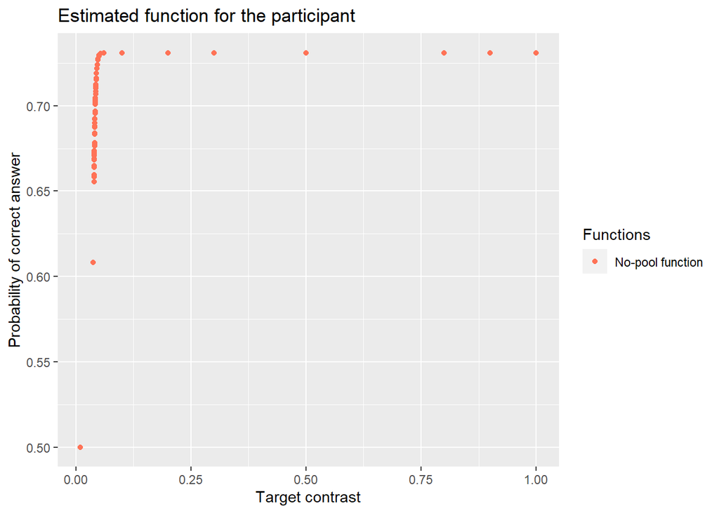

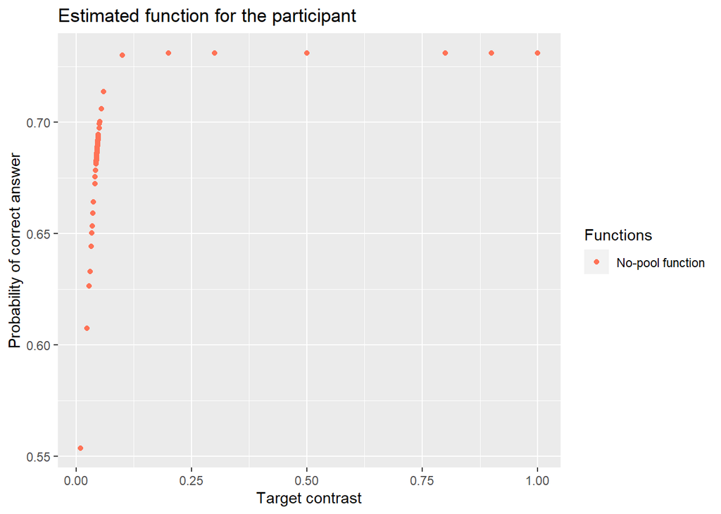

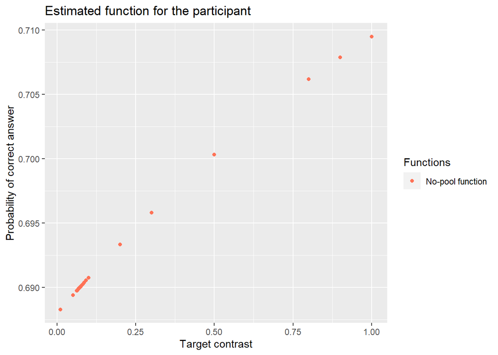

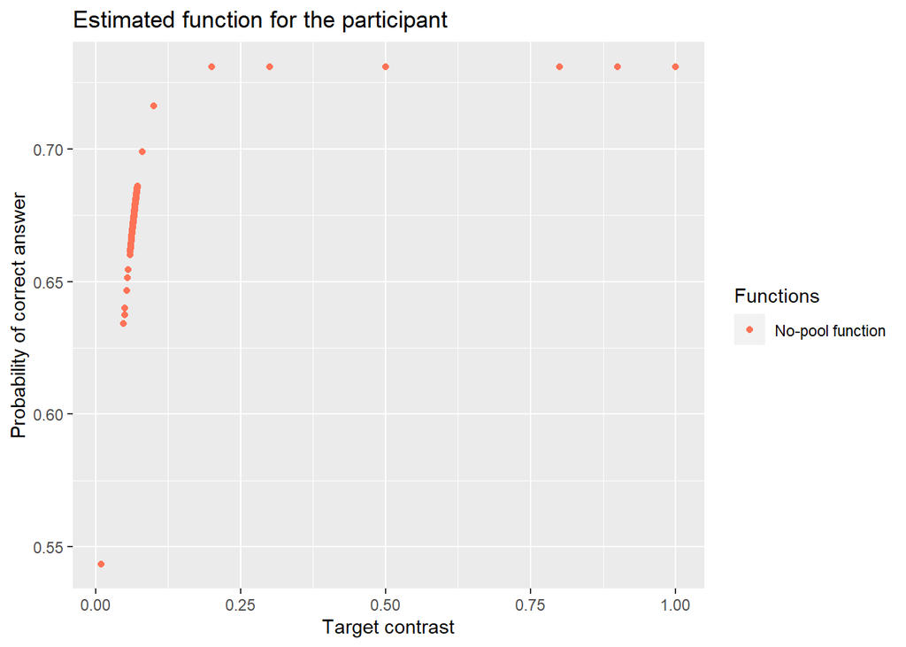

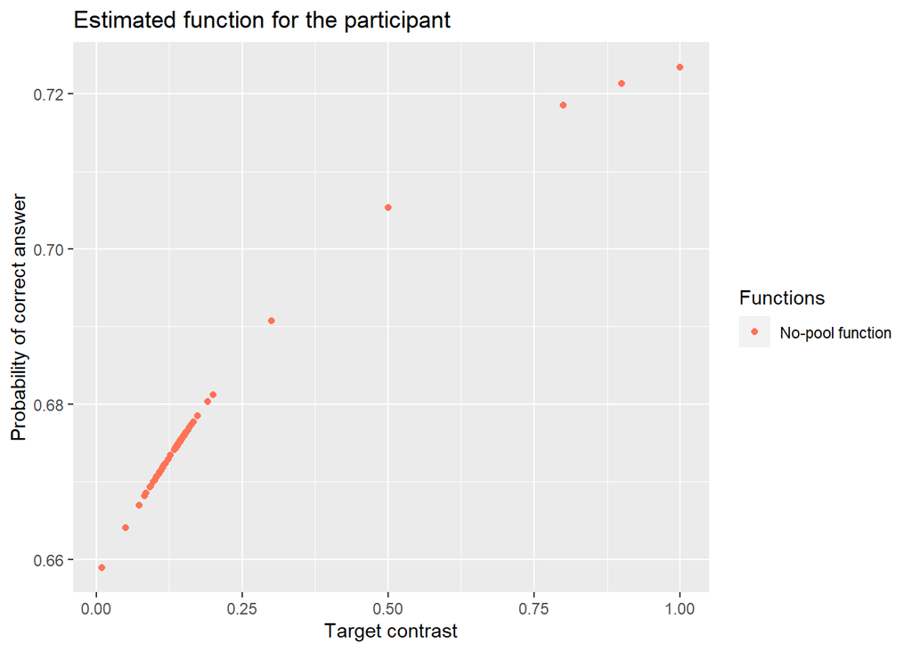

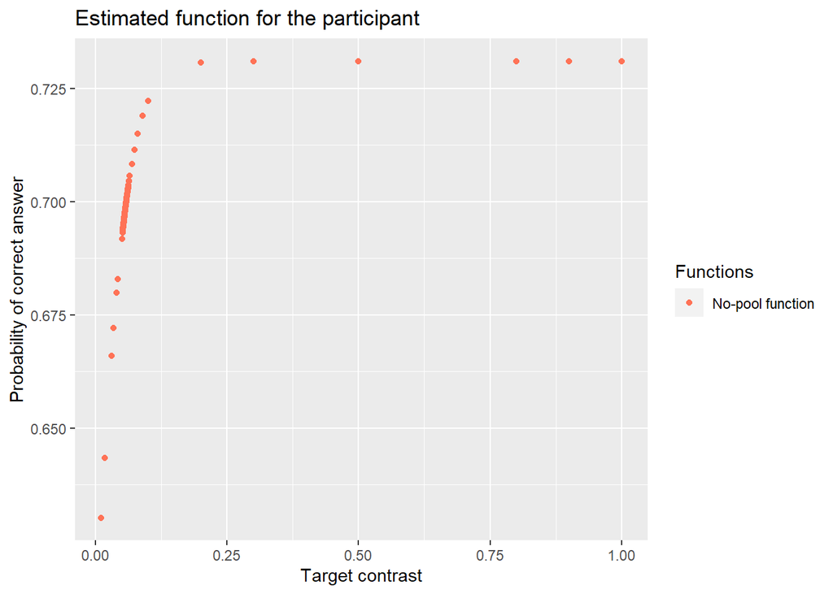

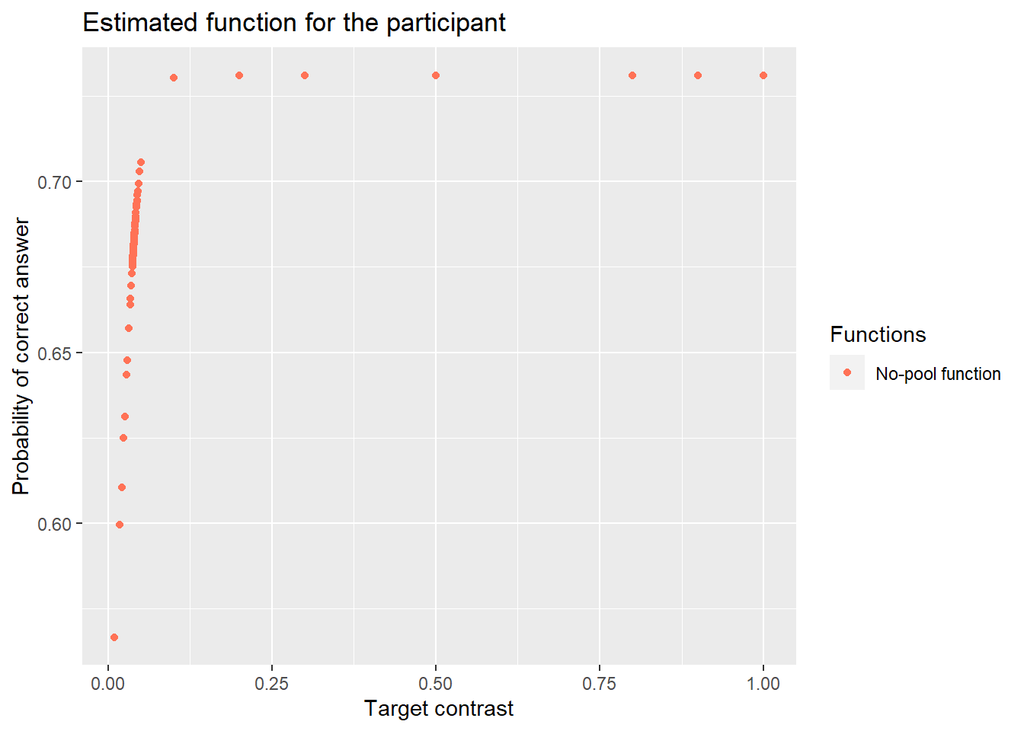

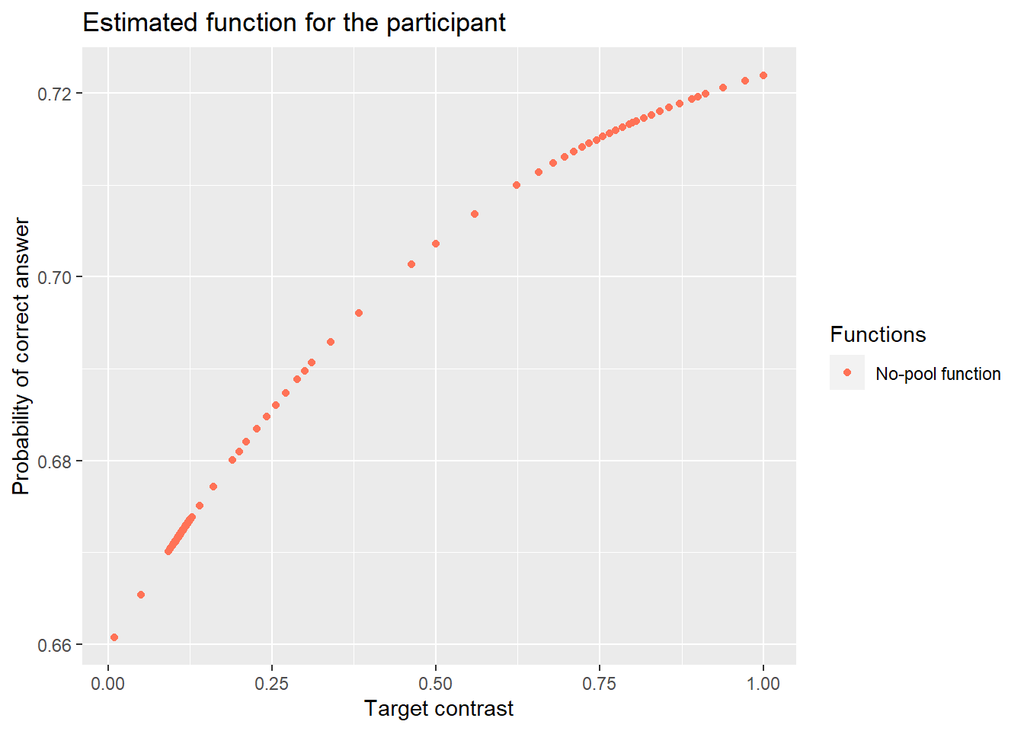

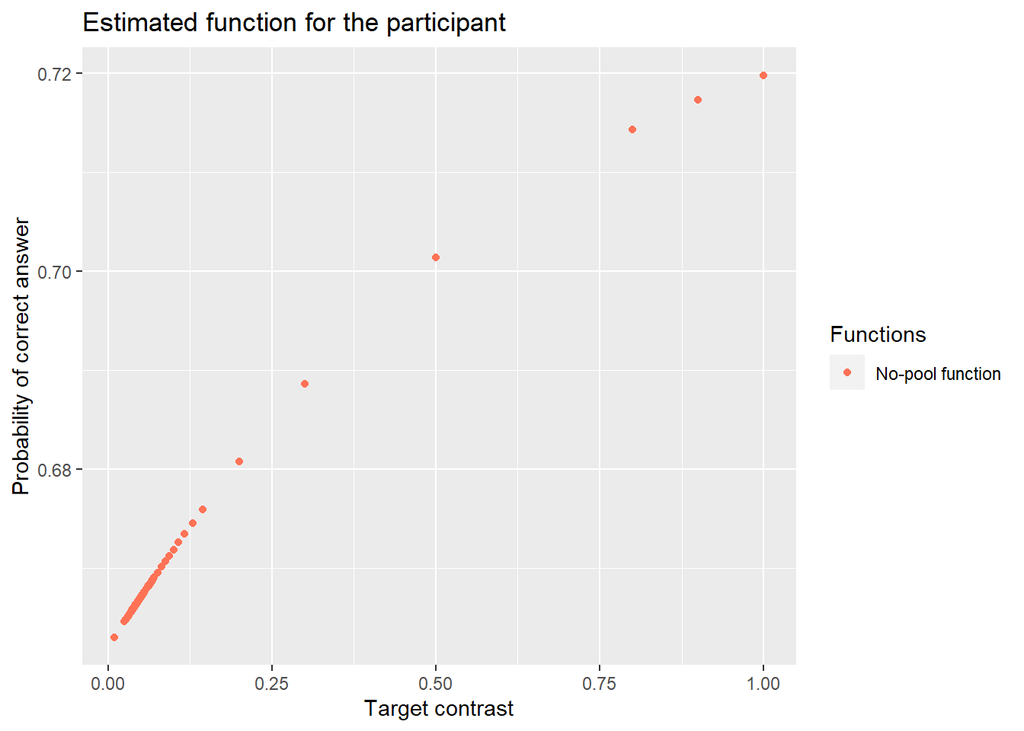

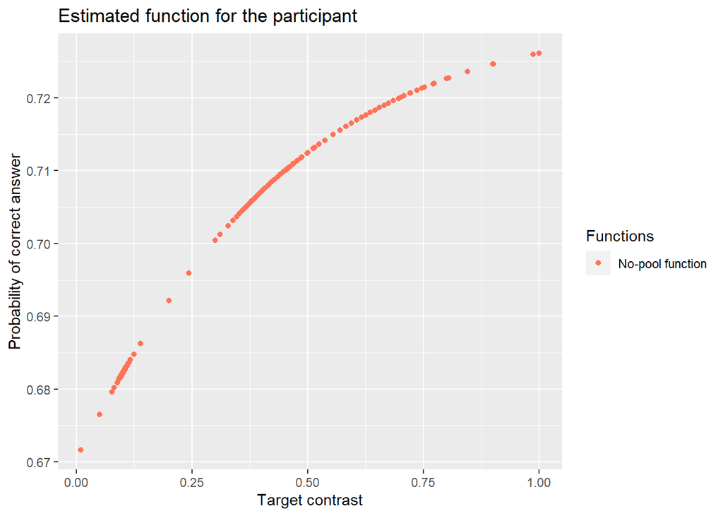

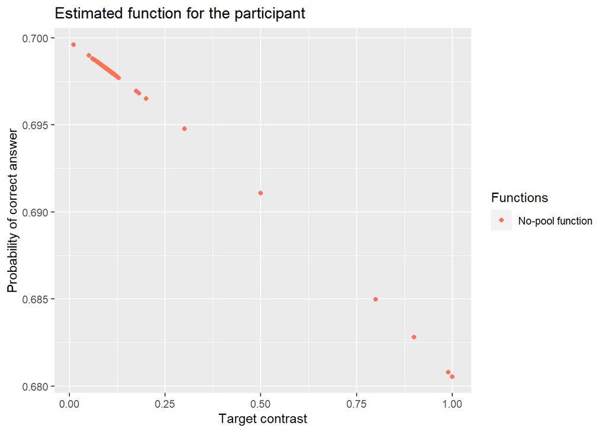

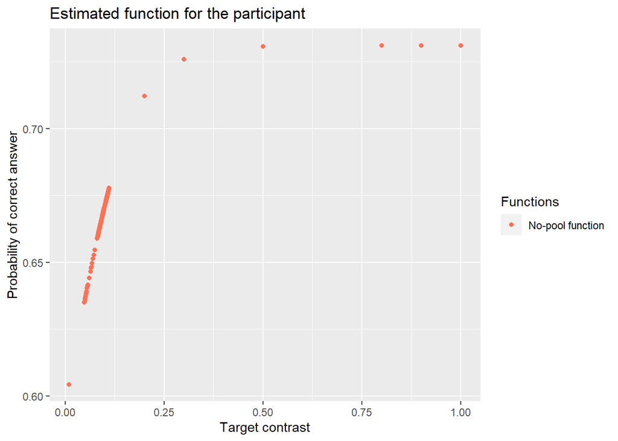

[17 more figures not shown]

```r
staircase <- df %>%
  filter(trial.type == "staircase") #isolate staircasing data

for (i in 1:29) {
  loopdf <- staircase %>%
    filter(subject == i) #isolate each subject since we are not organizing the data hierarchically, but rather analyzing everything with each participant entirely separate
  loopmodel <- glm(correct ~ target.contrast, data = loopdf, family = binomial) #run logistic regression on subject's data
  loopdf <- loopdf %>%
    mutate(inv = inv.logit(loopmodel$fitted.values)) #get the inverse logit of the fitted values
  plot <- ggplot(loopdf, aes(x = target.contrast, y = inv)) +
    geom_point(aes(color = "coral1")) +
    scale_color_manual(labels = c("No-pool function"), values = c("coral1")) +
    guides(color = guide_legend("Functions")) +
    labs(title = "Estimated function for the participant", x = "Target contrast", y = "Probability of correct answer") #plot the thus estimated function
  print(plot) #actually get the plot to show up
}
```

There does not appear to be sufficient data to plot the logistic functions: data points are sparse and the function is highly variable from participant to participant.

**iv. on top of those plots, add the estimated functions (on the *target.contrast* range from 0-1) for each subject based on a partial pooling model (use `glmer` from the package `lme4`) where unique intercepts and slopes for *target.contrast* are modelled for each *subject***

```r
model_1 <- lme4::glmer(correct ~ target.contrast + (1 | subject), family = binomial, data = staircase)
summary(model_1)
```

```
## Generalized linear mixed model fit by maximum likelihood (Laplace
##   Approximation) [glmerMod]
##  Family: binomial  ( logit )
## Formula: correct ~ target.contrast + (1 | subject)
##    Data: staircase
##
##      AIC      BIC   logLik deviance df.resid
##   5999.0   6018.9  -2996.5   5993.0     5600
##
## Scaled residuals:
##     Min      1Q  Median      3Q     Max
## -8.6646  0.1464  0.5603  0.5902  0.7214
##
## Random effects:
##  Groups  Name        Variance Std.Dev.
##  subject (Intercept) 0.03959  0.199
## Number of obs: 5603, groups:  subject, 29
##
## Fixed effects:
##                 Estimate Std. Error z value Pr(>|z|)
## (Intercept)      0.88538    0.06121   14.46  < 2e-16 ***
## target.contrast  3.20846    0.40207    7.98 1.47e-15 ***
## ---
## Signif. codes:  0 '***' 0.001 '**' 0.01 '*' 0.05 '.' 0.1 ' ' 1
##
## Correlation of Fixed Effects:
##             (Intr)
## trgt.cntrst -0.538
```

[figure not shown]

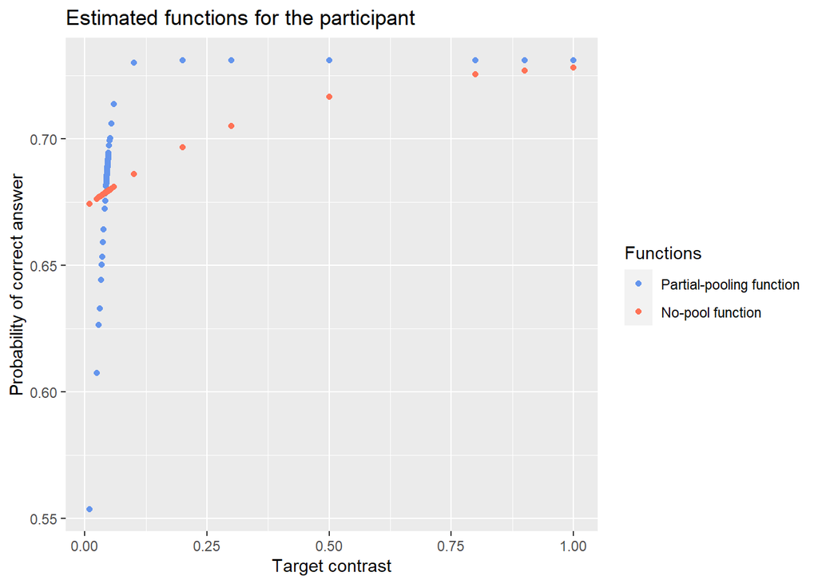

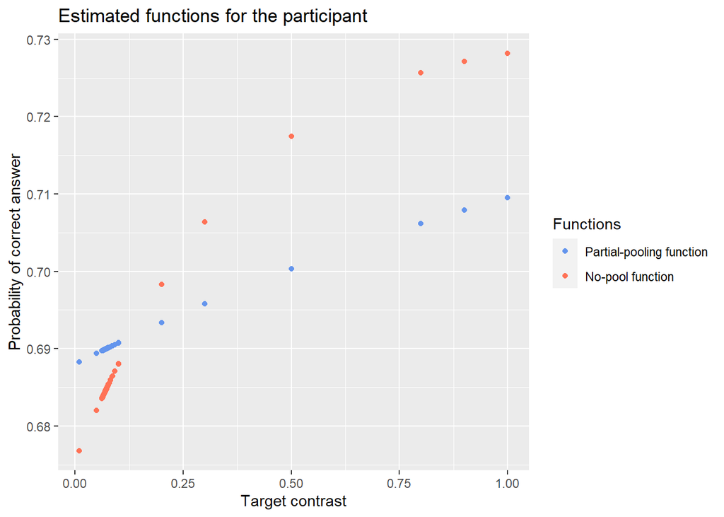

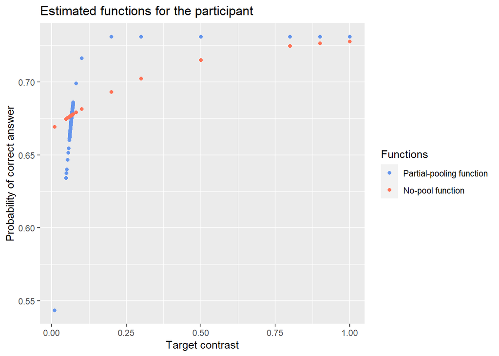

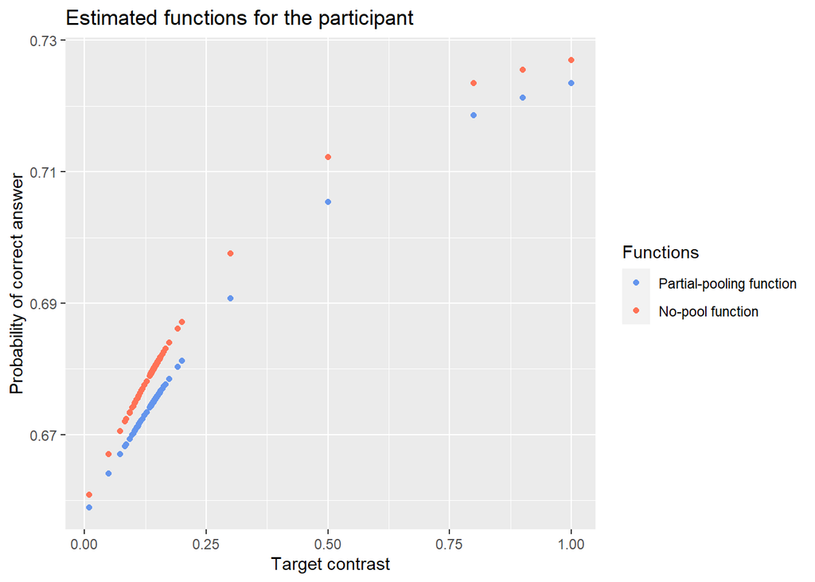

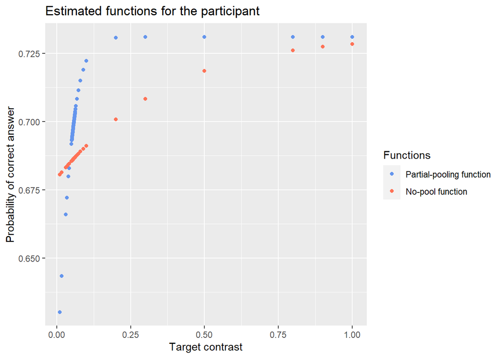

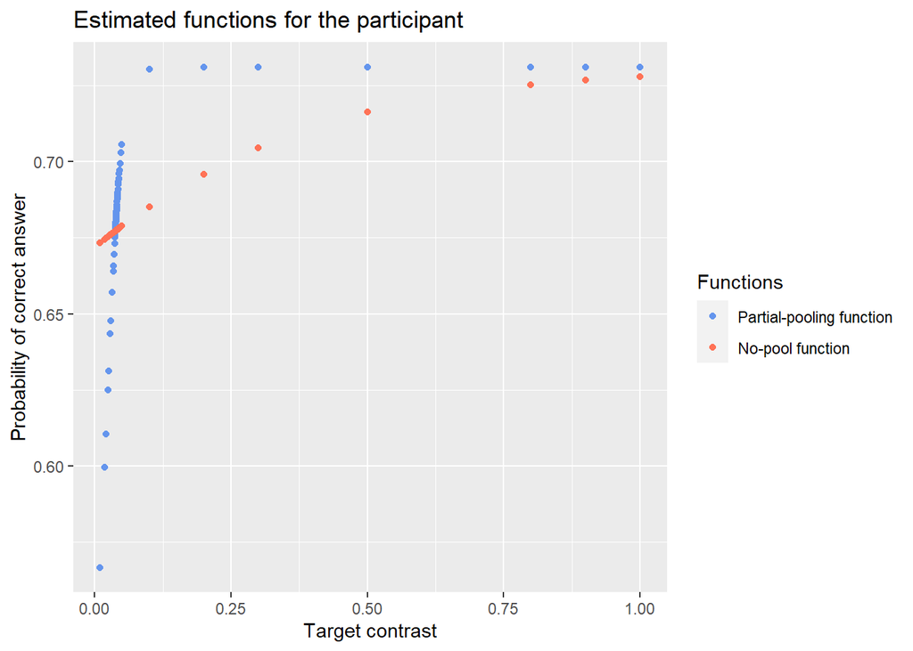

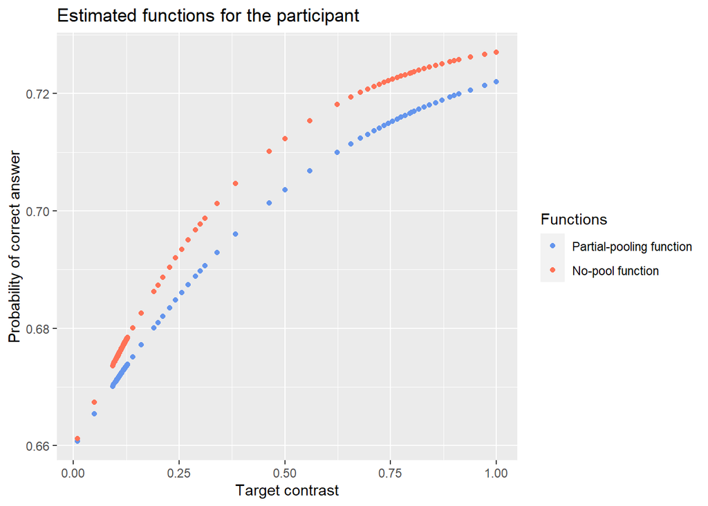

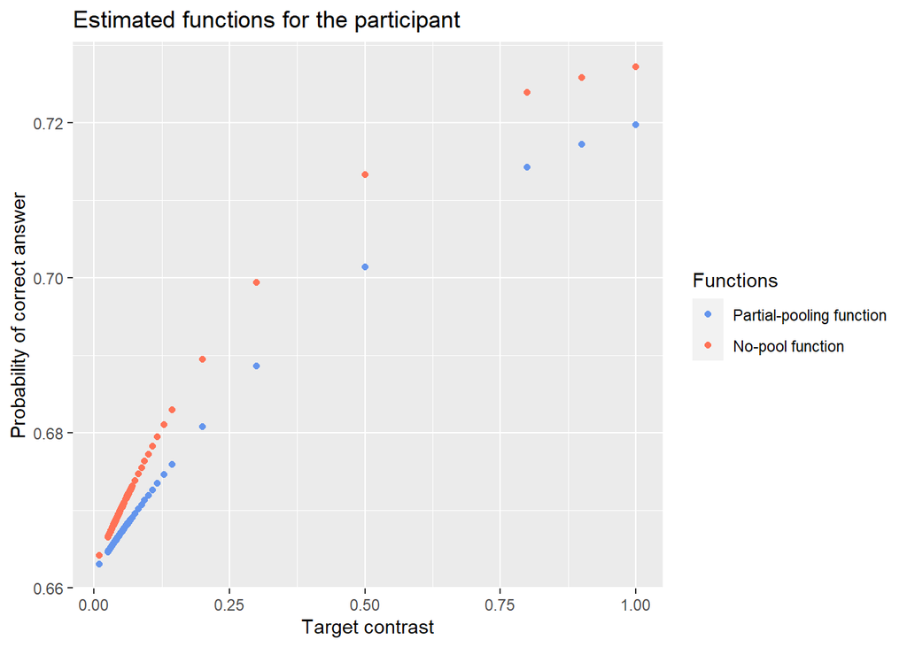

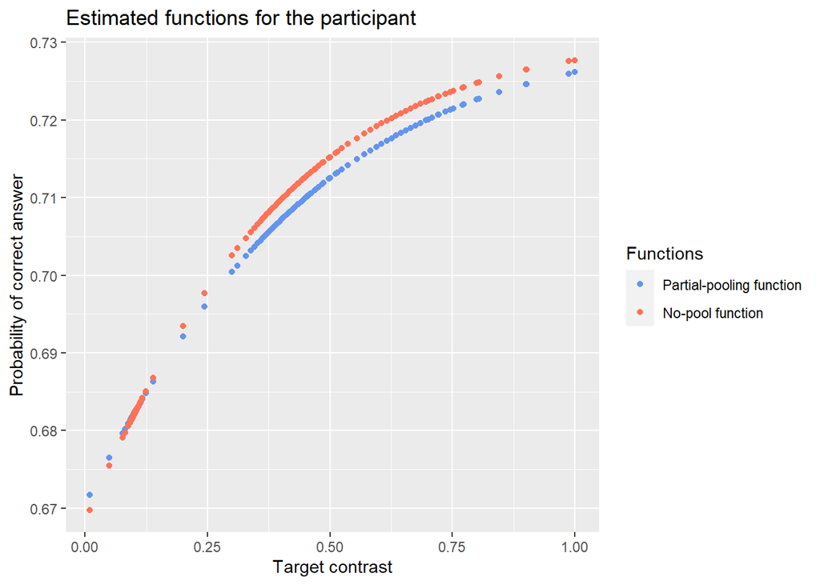

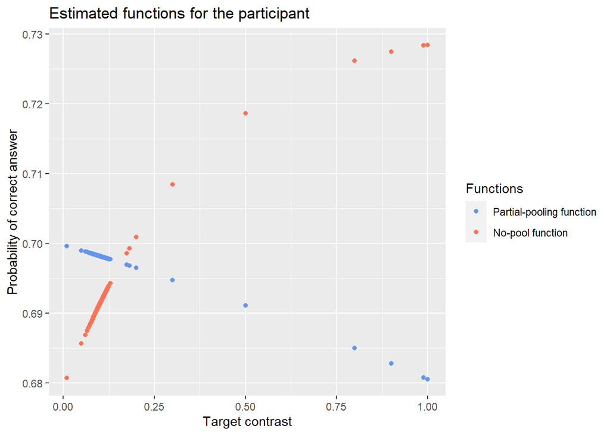

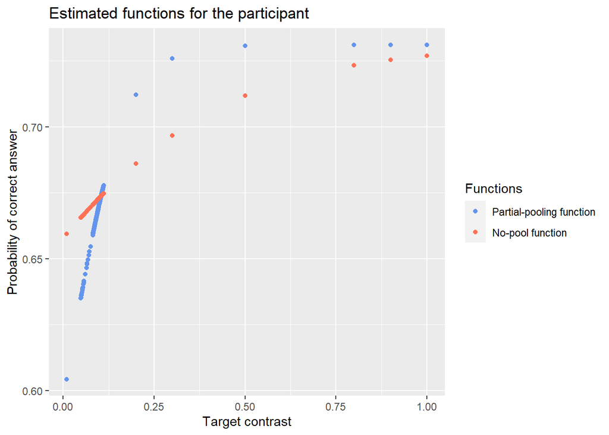

[17 more figures not shown]

```r
staircase <- staircase %>%
  mutate(pooled_inv = inv.logit(fitted.values(model_1)))

for (i in 1:29) {
  #same as in previous exercise
  loopdf <- staircase %>%
    filter(subject == i)
  loopmodel <- glm(correct ~ target.contrast, data = loopdf, family = binomial)
  loopdf <- loopdf %>%
    mutate(inv = inv.logit(loopmodel$fitted.values))
  #now for overlaying the pooled function
  plot <- ggplot(loopdf, aes(x = target.contrast, y = inv)) +
    geom_point(aes(y = inv, color = "coral1")) +
    geom_point(aes(y = pooled_inv, color = "cornflowerblue")) +
    scale_color_manual(labels = c("Partial-pooling function", "No-pool function"), values = c("cornflowerblue", "coral1")) +
    guides(color=guide_legend("Functions")) +
    labs(title = "Estimated functions for the participant", x = "Target contrast", y = "Probability of correct answer") #plot the thus estimated function
  print(plot) #actually get the plot to show up
}
```

**v. in your own words, describe how the partial pooling model allows for a better fit for each subject**

When the data is analyzed by taking each subject separately, only a small portion of the data is used (none of the other participants’ data is included, despite them having taken part in the same experiment under the same conditions). When using a hierarchical model, all of the data is used in order to calculate the estimated function, with the different subjects simply recognized as having *slightly* different curves that nevertheless resemble the overall curve, thereby allowing more general tendencies to be represented. Essentially, the hierarchical model recognizes both the differences and the similarities in the sample of participants.

## Exercise 2

Now we **only** look at the *experiment* trials (*trial.type*)

```r
exp <- df %>%
  filter(trial.type == "experiment")
```

### 1) Pick four subjects and plot their Quantile-Quantile (Q-Q) plots for the residuals of their objective response times (*rt.obj*) based on a model where only intercept is modeled

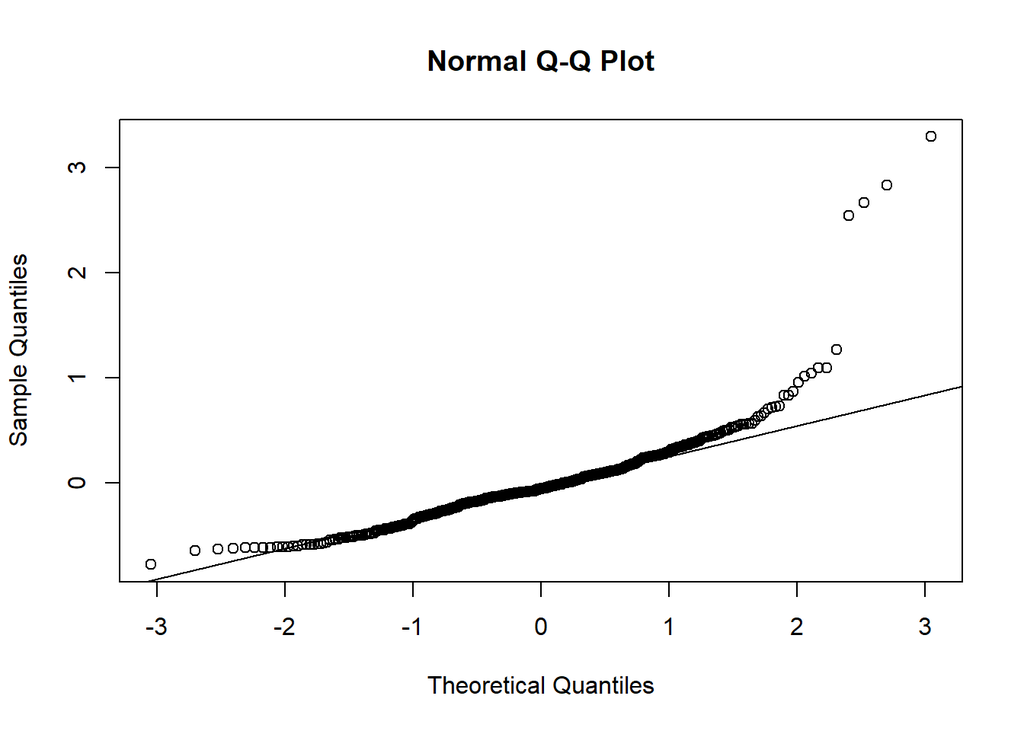

```r
# Isolate subjects
sub001 <- exp %>% filter(subject == "1")
sub005 <- exp %>% filter(subject == "5")
sub016 <- exp %>% filter(subject == "16")
sub020 <- exp %>% filter(subject == "20")

# Model only the intercept of their objective response times (basically the mean)
int001 <- lm(rt.obj ~ 1, data = sub001)
int005 <- lm(rt.obj ~ 1, data = sub005)
int016 <- lm(rt.obj ~ 1, data = sub016)
int020 <- lm(rt.obj ~ 1, data = sub020)

# Plot residuals with Q-Q plots
qqnorm(residuals(int001))
qqline(residuals(int001))
```

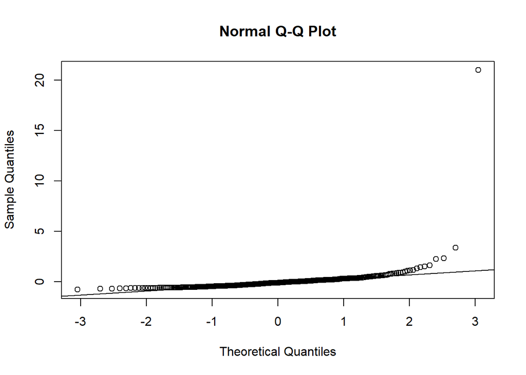

```r
qqnorm(residuals(int005))
qqline(residuals(int005))
```

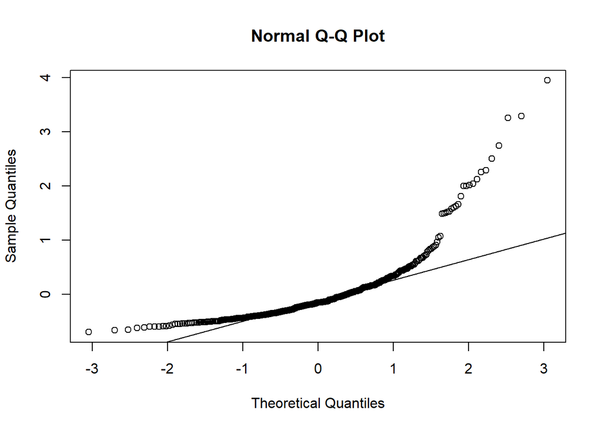

```r
qqnorm(residuals(int016))
qqline(residuals(int016))
```

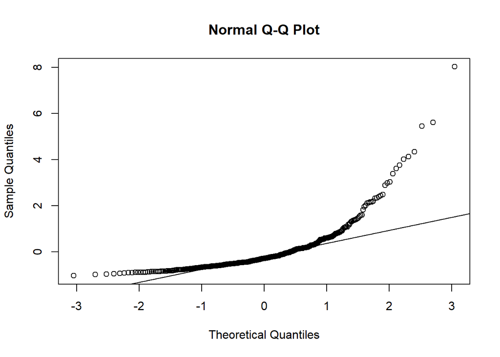

```r
qqnorm(residuals(int020))
qqline(residuals(int020))
```

**i. comment on these** Based on a visual inspection, the residuals are clearly not normally distributed (they do not approximate the line), and they are heavily skewed.

**ii. does a log-transformation of the response time data improve the Q-Q-plots?**

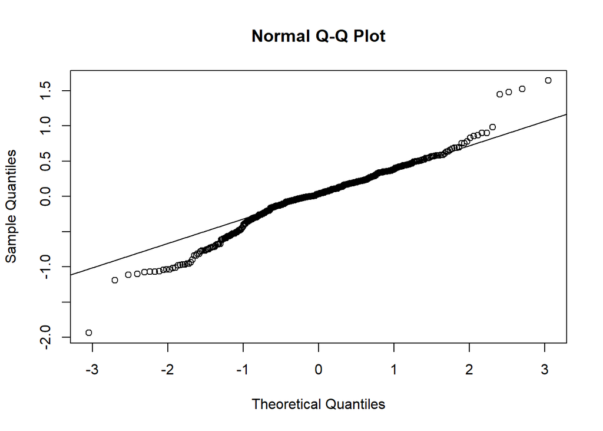

```r
#Log-transform variables
sub001$log.rt.obj <- log(sub001$rt.obj)
sub005$log.rt.obj <- log(sub005$rt.obj)
sub016$log.rt.obj <- log(sub016$rt.obj)
sub020$log.rt.obj <- log(sub020$rt.obj)

# Model intercepts
log.int001 <- lm(log.rt.obj ~ 1, data = sub001)
log.int005 <- lm(log.rt.obj ~ 1, data = sub005)
log.int016 <- lm(log.rt.obj ~ 1, data = sub016)
log.int020 <- lm(log.rt.obj ~ 1, data = sub020)

# Plot residuals with Q-Q plots
qqnorm(residuals(log.int001))
qqline(residuals(log.int001))
```

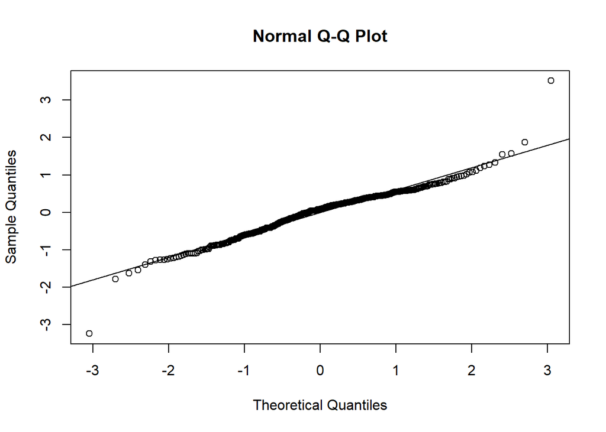

```r
qqnorm(residuals(log.int005))
qqline(residuals(log.int005))
```

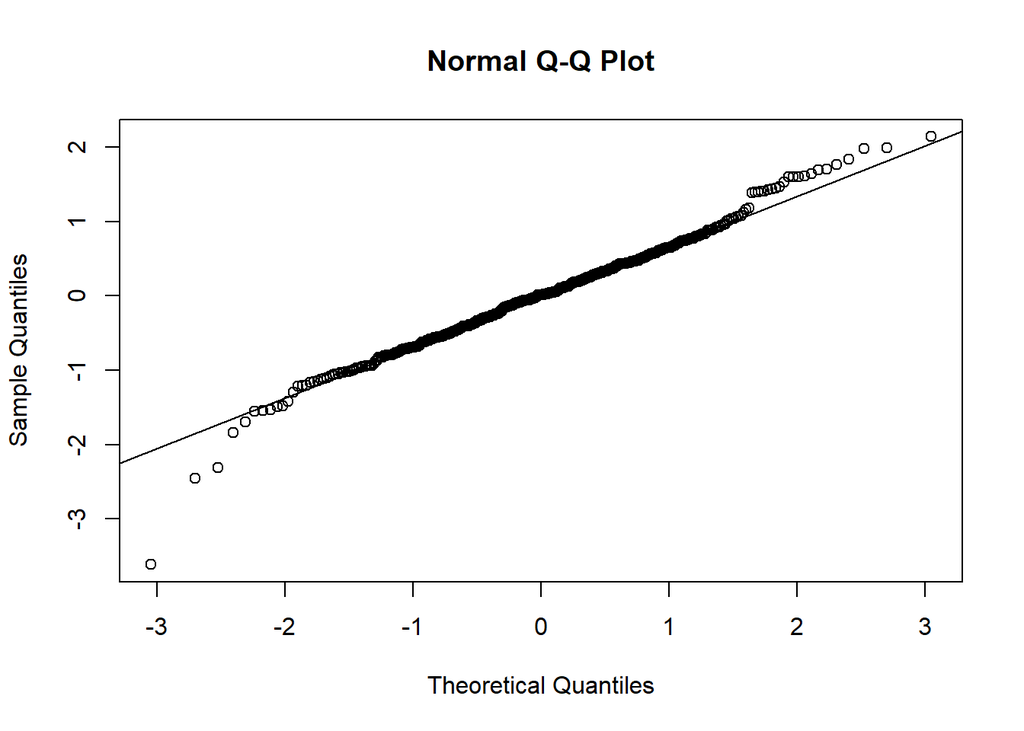

```r
qqnorm(residuals(log.int016))
qqline(residuals(log.int016))
```

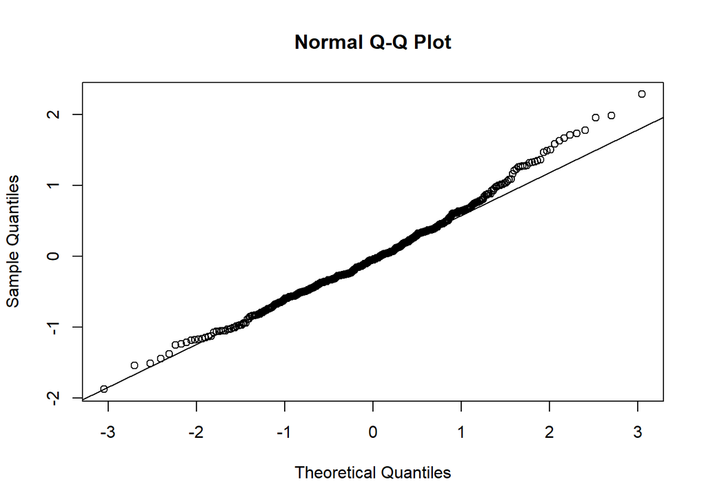

```r
qqnorm(residuals(log.int020))
qqline(residuals(log.int020))
```

The residuals appear to better approximate a normal distribution after log-transformation, although they still exhibit a certain amount of skewness (much less than the non-transformed residuals).

### 2) Now do a partial pooling model modeling objective response times as dependent on *task*. (set `REML=FALSE` in your `lmer`-specification)

```r
#Why REML = FALSE?
#It’s generally good to use REML, if it is available, when you are interested in the magnitude of the random effects variances, but never when you are comparing models with different fixed effects via hypothesis tests or information-theoretic criteria such as AIC.

# Build models
model_2.1 <- lme4::lmer(rt.obj ~ task + (1 | subject),
                        data = exp,
                        REML = FALSE)
```

**i. which would you include among your random effects and why? (support your choices with relevant measures, taking into account variance explained and number of parameters going into the modeling)**

*Subject* has to be included as a random effect as it represents sub-groups that significantly influence the outcome and make the data non-independent.

**ii. explain in your own words what your chosen models says about response times between the different tasks**

```r
fixef(model_2.1)
```

```
##    (Intercept) taskquadruplet    tasksingles
##      1.1200841     -0.1532473     -0.1915364
```

The model shows that reaction times are highest for pairs tasks (α = 1.1201), with somewhat lower reaction times for singles tasks (β = -0.1915) and quadruplet tasks (β = -0.1532).

### 3) Now add *pas* and its interaction with *task* to the fixed effects

```r
#When you want to model both main effects and their interactions, use an asterisk (*) between the effects. When you want to model ONLY the interaction, use a colon (:).
model_2.2 <- lmerTest::lmer(rt.obj ~ pas * task + (1 | subject),
                            data = exp,
                            REML = FALSE)
```

**i. how many types of group intercepts (random effects) can you add without ending up with convergence issues or singular fits?**

```r
model_2.3 <- lmerTest::lmer(rt.obj ~ task +
                              (1 | subject) +
                              (1 | cue) +
                              (1 | trial) +
                              (1 | target.type) +
                              (1 | pas),
                            data = exp,
                            REML = FALSE) # this model still converges
model_2.4 <- lmerTest::lmer(rt.obj ~ task +
                              (1 | subject) +
                              (1 | cue) +
                              (1 | trial) +
                              (1 | target.type) +
                              (1 | pas) +
                              (1 | task),
                            data = exp,
                            REML = FALSE) # this model gives a singular fit
```

We succeeded at adding 5 group intercepts before singularity issues happened.

**ii. create a model by adding random intercepts (without modelling slopes) that results in a singular fit - then use `print(VarCorr(<your.model>), comp='Variance')` to inspect the variance vector - explain why the fit is singular (Hint: read the first paragraph under details in the help for `isSingular`)**

```r
# I take the model with singularity issues from the previous exercise
print(VarCorr(model_2.4), comp = 'Variance')
```

```
##  Groups      Name        Variance
##  trial       (Intercept) 0.0020319
##  cue         (Intercept) 0.0957207
##  subject     (Intercept) 0.1000015
##  pas         (Intercept) 0.0347612
##  task        (Intercept) 0.0000000
##  target.type (Intercept) 0.0025884
##  Residual                8.1138210
```

**iii. in your own words - how could you explain why your model would result in a singular fit?**

When a group intercept is modeled, it is because the grouping variable accounts for some variance in the data - e.g. in within-subject experiments, participants will generally have their own baseline for performance. In other words, by modeling a separate regression line for the data points belonging to the group, there is less distance between the points and the regression line for the group (i.e. less error). The extent of this ‘improvement’ can be calculated as the variance explained by the grouping variable.

This same can be done for all other group effects modeled. However, at some point, the combinations of these groupings will create smaller and smaller subgroups, fitting group effects to fewer and fewer data points, to the extent that almost no error will be present for each line because they pretty much lie *on* the data points. In this case, the model no longer *summarizes* the data, but rather *conforms* to it, i.e. we have overfitted it.

## Exercise 3

### 1) Initialise a new data frame, `data.count`. *count* should indicate the number of times they categorized their experience as *pas* 1-4 for each *task*. I.e. the data frame would have for subject 1: for task:singles, pas1 was used # times, pas2 was used # times, pas3 was used # times and pas4 was used # times. You would then do the same for task:pairs and task:quadruplet

```r
data.count <- df %>%
  group_by(subject, task, pas) %>%
  summarise('count' = n()) #create grouping data frame

data.count$subject <- as.factor(data.count$subject)
data.count$task <- as.factor(data.count$task)
data.count$pas <- as.factor(data.count$pas)
data.count$count <- as.integer(data.count$count) #ensure correct data format
```